# Projet Tendance Mode

Marie-Anne Randrianarivony

2026-05-27

# Chargement des packages et des données

```r
library(tidyverse)
library(janitor)
library(skimr)
library(ggplot2)
library(tidytext)
library(textdata)
library(tidymodels)
library(randomForest)
```

```r
reviews  <- read.csv("C:/Users/Marie-Anne/OneDrive - Université du Québec à Chicoutimi/Documents/Projet-classification-des-tendances-de-mode-f-minin/data/Womens Clothing E-Commerce Reviews.csv", na.strings=c("","NA"))
```

Étant donné qu’on cherche à classifier les tendances de mode féminin basé sur les avis des clients. La variable cible sera donc la colonne `Recommended.ID`.

# 1. Nettoyage des données

## Apercu du jeu de donnée et gestion des valeurs manquantes

```r
skim(reviews)
```

Data summary

| Name | reviews |
| --- | --- |
| Number of rows | 23486 |
| Number of columns | 11 |
| _______________________ |  |
| Column type frequency: |  |
| character | 5 |
| numeric | 6 |
| ________________________ |  |
| Group variables | None |

**Variable type: character**

| skim_variable | n_missing | complete_rate | min | max | empty | n_unique | whitespace |
| --- | --- | --- | --- | --- | --- | --- | --- |
| Title | 3810 | 0.84 | 2 | 52 | 0 | 13993 | 0 |
| Review.Text | 845 | 0.96 | 9 | 508 | 0 | 22634 | 0 |
| Division.Name | 14 | 1.00 | 7 | 14 | 0 | 3 | 0 |
| Department.Name | 14 | 1.00 | 4 | 8 | 0 | 6 | 0 |
| Class.Name | 14 | 1.00 | 4 | 14 | 0 | 20 | 0 |

**Variable type: numeric**

| skim_variable | n_missing | complete_rate | mean | sd | p0 | p25 | p50 | p75 | p100 | hist |
| --- | --- | --- | --- | --- | --- | --- | --- | --- | --- | --- |
| X | 0 | 1 | 11742.50 | 6779.97 | 0 | 5871.25 | 11742.5 | 17613.75 | 23485 | ▇▇▇▇▇ |
| Clothing.ID | 0 | 1 | 918.12 | 203.30 | 0 | 861.00 | 936.0 | 1078.00 | 1205 | ▁▁▁▇▇ |
| Age | 0 | 1 | 43.20 | 12.28 | 18 | 34.00 | 41.0 | 52.00 | 99 | ▅▇▃▁▁ |
| Rating | 0 | 1 | 4.20 | 1.11 | 1 | 4.00 | 5.0 | 5.00 | 5 | ▁▁▂▃▇ |
| Recommended.IND | 0 | 1 | 0.82 | 0.38 | 0 | 1.00 | 1.0 | 1.00 | 1 | ▂▁▁▁▇ |
| Positive.Feedback.Count | 0 | 1 | 2.54 | 5.70 | 0 | 0.00 | 1.0 | 3.00 | 122 | ▇▁▁▁▁ |

```r
sum(is.na(reviews))
```

```
## [1] 4697
```

Les colonnes `title`, `Review.Text`, `Division.Name`, `Department.Name`, `Class.Name` contiennent des valeurs manquantes.

Nous avons 11 variables pour 23486 observations.

```r
reviews <- reviews %>%
  select(-X)
```

## Renommage des colonnes

```r
reviews <- reviews %>%
  rename(
    clothing_id = Clothing.ID,
    age = Age,
    title = Title,
    review = Review.Text,
    rating = Rating,
    recommended = Recommended.IND,
    feedback_positif = Positive.Feedback.Count,
    division = Division.Name,
    department = Department.Name,
    class = Class.Name
  )
```

## Traitement des valeurs manquantes

On a constaté récemment qu’il y avait 14 valeurs manquantes dans chacune des colonnes `department`,`division`, `class`. Étant donné que ce n’est pas un nombre important de données comparé au 23486 observations. On peut donc les supprimer. Concernant les colonnes `title`, on observe 3810 valeurs manquantes. Pour la colonne `review`, on observe 845 valeurs manquantes. Il s’agit là d’un nombre minimal comparé aux nombres d’observations alors on peut les supprimer également.

```r
reviews <- reviews %>%
  filter(!is.na(title),!is.na(review),!is.na(department), !is.na(division), !(is.na(class)))
```

# 2. Analyse exploratoire des données

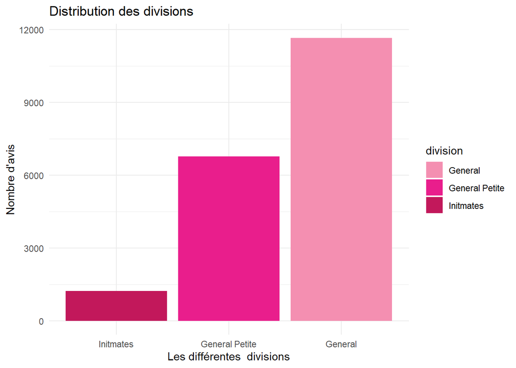

```r
reviews %>%
  count(division) %>%
  ggplot(aes(x =fct_reorder(division,n), y=n, fill=division)) +
  geom_col() +
    scale_fill_manual(values = c("#F48FB1", "#E91E8C", "#C2185B")) +
labs(title = "Distribution des divisions",x="Les différentes  divisions", y ="Nombre d'avis") +
  theme_minimal()
```

**12000** des avis des clients concernent la division **Général**.

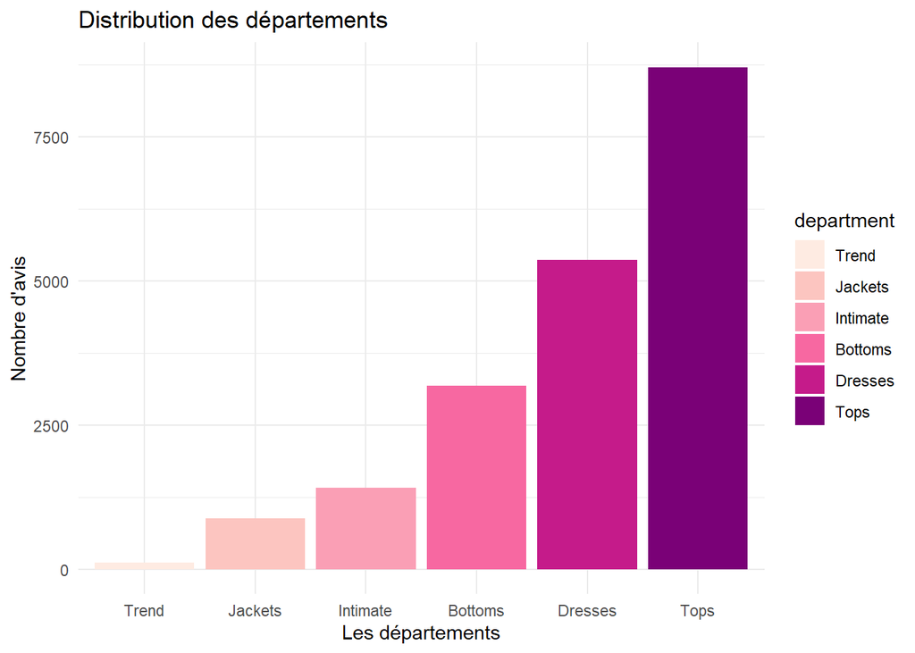

```r
reviews %>%
  count(department) %>%
  mutate(department = fct_reorder(department, n)) %>%
  ggplot(aes(x = department, y=n, fill = department)) +
  geom_col() +
  scale_fill_brewer(palette = "RdPu") +
  labs(title = "Distribution des départements", x= "Les départements", y ="Nombre d'avis") +
  theme_minimal()
```

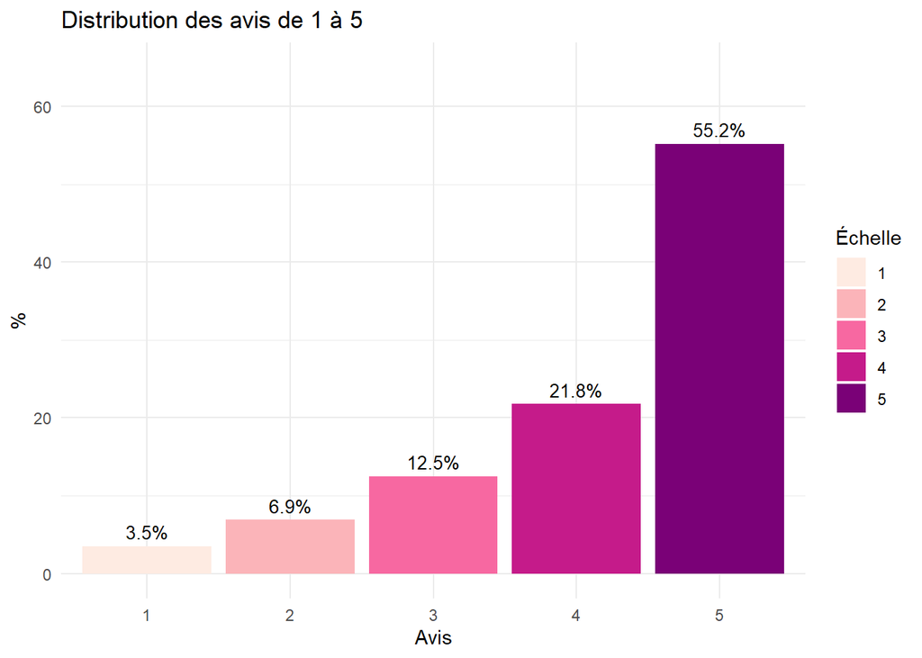

```r
reviews %>%
  count(rating) %>%
  mutate(pct = round(n/ sum(n)*100, 1)) %>%
  ggplot(aes(x= factor(rating), y=pct, fill=factor(rating))) +
  geom_col() +
 scale_fill_brewer(palette = "RdPu") +
  geom_text(aes(label = paste0(pct, "%")), vjust = -0.5, size = 3.5) +
  ylim(0, 65) +
  labs(title = "Distribution des avis de 1 à 5", x= "Avis", y="%", fill="Échelle") +
  theme_minimal()
```

Environ la **moitié des avis** laissés par les clients sont notés à **la note maximale 5**.

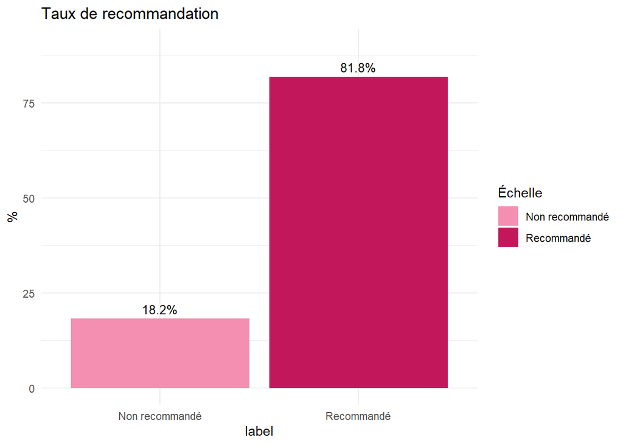

```r
reviews %>%
  count(recommended) %>%
  mutate(
    label = if_else(recommended ==1, "Recommandé", "Non recommandé"),
    pct = round(n/sum(n) *100,1)
  ) %>%
  ggplot(aes(x = label, y = pct, fill=label)) +
  geom_col() +
    scale_fill_manual(values = c("#F48FB1", "#C2185B")) +
  geom_text(aes(label= paste0(pct, "%")), vjust = -0.5, size = 3.5) +
  ylim(0,90) +
  labs(title="Taux de recommandation", y="%", fill="Échelle") +
  theme_minimal()
```

81,8% des clients recommandent les vêtements qu’ils ont laissés des avis.

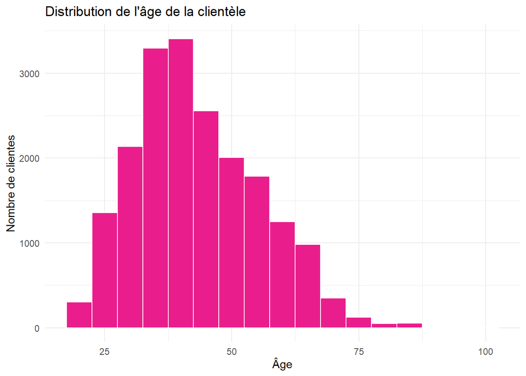

```r
reviews %>%
  ggplot(aes(x=age)) +
  geom_histogram(binwidth = 5, fill="#E91E8C", color="white") +
  labs(title= "Distribution de l'âge de la clientèle", x="Âge", y="Nombre de clientes") +
  theme_minimal()
```

# 3. Enrichissement des données

## Ajout des colonnes nbr_mots, nbr_char, groupe_age

```r
reviews <- reviews %>%
  mutate(
    nbr_mots = lengths(strsplit(review, " ")),
    nbr_char = nchar(review),
    groupe_age = case_when(
      age < 30 ~"moins de 30 ans",
      age >=30 & age < 40 ~ " 30 et 40 ans",
      age >=40 & age < 60 ~ " 40 et 60 ans",
      TRUE   ~"60 ans et plus"
    ),
    groupe_age = factor(groupe_age)
  )
```

## Extraction des mots-clés

On va aussi extraire les avis ayant des mots-clés qui indiqueront potentiellement si une cliente recommande le produit ou non. En prenant seulement les mots-clés à connotation positive.

```r
reviews <- reviews %>%
  mutate(
  fit = as.integer(str_detect(tolower(review), "fit|fits|fitted")),
  quality = as.integer(str_detect(tolower(review), "quality|material|fabric")),
 color = as.integer(str_detect(tolower(review), "color|colour|pattern")),
love = as.integer(str_detect(tolower(review), "love|lovely|beautiful")),
size = as.integer(str_detect(tolower(review), "size|sizing|small|large|petite|medium|big"))
)
```

```r
reviews %>%
  select(review, fit, quality, size, love) %>%
  head(5)
```

```
##                                                                                                                                                                                                                                                                                                          …
## 1 I had such high hopes for this dress and really wanted it to work for me. i initially ordered the petite small (my usual size) but i found this to be outrageously small. so small in fact that i could not zip it up! i reordered it in petite medium, which was just ok. overall, the top half was co…
## 2                                                                                                                                                                                                                                                                                                        …
## 3                                                                                                                                                                                                                                                                                                        …
## 4             I love tracy reese dresses, but this one is not for the very petite. i am just under 5 feet tall and usually wear a 0p in this brand. this dress was very pretty out of the package but its a lot of dress. the skirt is long and very full so it overwhelmed my small frame. not a strange…
## 5     I aded this in my basket at hte last mintue to see what it would look like in person. (store pick up). i went with teh darkler color only because i am so pale :-) hte color is really gorgeous, and turns out it mathced everythiing i was trying on with it prefectly. it is a little baggy on me…
##   fit quality size love
## 1   1       0    1    0
## 2   0       0    0    1
## 3   0       0    0    1
## 4   0       0    1    1
## 5   0       0    1    0
```

# 4. Analyse des sentiments: sentiments positifs et sentiments négatifs

Il faudra classer les mots en deux catégories positifs et négatifs. Pour cela, on utilisera le lexique Bing crée par les chercheurs Bing Liu et Al.

```r
sentiments_bing <- reviews %>%
  select(clothing_id, review) %>%
  unnest_tokens(word, review) %>%
  inner_join(get_sentiments("bing"), by = "word") %>%
  count(clothing_id, sentiment) %>%
  pivot_wider(
    names_from = sentiment,
    values_from = n,
    values_fill = 0,
    names_prefix = "sent_"
  ) %>%
  mutate(score_sentiment = sent_positive - sent_negative)

head(sentiments_bing)
```

```
## # A tibble: 6 × 4
##   clothing_id sent_negative sent_positive score_sentiment
##         <int>         <int>         <int>           <int>
## 1           1             6            14               8
## 2           2             3             7               4
## 3           4             0             7               7
## 4           5             0             3               3
## 5           7             0             6               6
## 6           8            10            23              13
```

## Jointure des données sur les sentiments avec le jeu de donnée principal

```r
reviews <- reviews %>%
  left_join(sentiments_bing, by ="clothing_id")

reviews <- reviews %>%
  mutate(
    sent_positive = replace_na(sent_positive, 0),
    sent_negative = replace_na(sent_negative, 0),
    score_sentiment = replace_na(score_sentiment, 0)
  )

glimpse(reviews)
```

```
## Rows: 19,662
## Columns: 21
## $ clothing_id      <int> 1077, 1049, 847, 1080, 858, 858, 1077, 1077, 1077, 10…
## $ age              <int> 60, 50, 47, 49, 39, 39, 24, 34, 53, 53, 44, 50, 47, 3…
## $ title            <chr> "Some major design flaws", "My favorite buy!", "Flatt…
## $ review           <chr> "I had such high hopes for this dress and really want…
## $ rating           <int> 3, 5, 5, 2, 5, 4, 5, 5, 3, 5, 5, 3, 4, 3, 5, 5, 5, 4,…
## $ recommended      <int> 0, 1, 1, 0, 1, 1, 1, 1, 0, 1, 1, 1, 1, 1, 1, 1, 1, 1,…
## $ feedback_positif <int> 0, 0, 6, 4, 1, 4, 0, 0, 14, 2, 0, 1, 3, 2, 0, 0, 0, 2…
## $ division         <chr> "General", "General Petite", "General", "General", "G…
## $ department       <chr> "Dresses", "Bottoms", "Tops", "Dresses", "Tops", "Top…
## $ class            <chr> "Dresses", "Pants", "Blouses", "Dresses", "Knits", "K…
## $ nbr_mots         <int> 98, 22, 36, 98, 101, 97, 34, 72, 66, 91, 66, 96, 95, …
## $ nbr_char         <int> 500, 124, 192, 488, 496, 482, 166, 360, 336, 502, 374…
## $ groupe_age       <fct> 60 ans et plus,  40 et 60 ans,  40 et 60 ans,  40 et …
## $ fit              <int> 1, 0, 0, 0, 0, 0, 0, 1, 1, 1, 1, 1, 1, 0, 1, 1, 1, 1,…
## $ quality          <int> 0, 0, 0, 0, 0, 0, 0, 1, 1, 1, 0, 1, 1, 1, 0, 0, 0, 0,…
## $ color            <int> 0, 0, 0, 1, 1, 1, 0, 0, 0, 1, 0, 0, 1, 1, 0, 0, 0, 0,…
## $ love             <int> 0, 1, 1, 1, 0, 0, 1, 1, 0, 1, 0, 0, 0, 0, 0, 0, 1, 0,…
## $ size             <int> 1, 0, 0, 1, 1, 1, 1, 1, 1, 0, 1, 1, 1, 1, 0, 1, 1, 1,…
## $ sent_negative    <int> 303, 29, 3, 274, 24, 24, 303, 303, 303, 426, 1, 303, …
## $ sent_positive    <int> 1099, 131, 21, 1115, 82, 82, 1099, 1099, 1099, 1286, …
## $ score_sentiment  <int> 796, 102, 18, 841, 58, 58, 796, 796, 796, 860, 1, 796…
```

## Transformation de la variable “recommended” en catégorielle

```r
reviews <- reviews %>%
  mutate(
    recommended = factor(recommended, levels=c(0,1),
    labels = c("Non","Oui")),
    groupe_age = factor(groupe_age)
  )
```

# Modélisation

La variable cible `recommended` étant binaire (Oui/Non), le modèle sera une classification. Il sera **supervisé** car la variable est déjà étiquetée.

## Régression Logistique

### Construction du modèle

```r
modele <- reviews %>%
  drop_na() %>%
  mutate(
    recommended = if_else(recommended == "Oui", 1, 0),
    department = factor(department),
    division = factor(division),
    class = factor(class),
    group_age = factor(groupe_age)
  )
```

### Séparation du jeu d’entraînement et du jeu de test

```r
set.seed(42)
train_idx <- sample(nrow(modele), 0.8 * nrow(modele))
train <- modele[train_idx, ]
test <- modele[-train_idx, ]
```

### Entraînement

```r
modele_log <- glm(
  recommended ~ feedback_positif + department + fit + quality + color + love + size + score_sentiment +  sent_positive,
  data = train,
  family = binomial
)

summary(modele_log)
```

```
##
## Call:
## glm(formula = recommended ~ feedback_positif + department + fit +
##     quality + color + love + size + score_sentiment + sent_positive,
##     family = binomial, data = train)
##
## Coefficients:
##                      Estimate Std. Error z value Pr(>|z|)
## (Intercept)         1.4165677  0.0683730  20.718  < 2e-16 ***
## feedback_positif   -0.0173699  0.0031303  -5.549 2.87e-08 ***
## departmentDresses  -0.3175740  0.0811235  -3.915 9.05e-05 ***
## departmentIntimate  0.0574269  0.1005019   0.571 0.567728
## departmentJackets  -0.0452515  0.1186009  -0.382 0.702800
## departmentTops     -0.3531119  0.0668506  -5.282 1.28e-07 ***
## departmentTrend    -0.4777787  0.2636599  -1.812 0.069970 .
## fit                 0.3468936  0.0450415   7.702 1.34e-14 ***
## quality            -0.5702587  0.0428740 -13.301  < 2e-16 ***
## color               0.2119969  0.0473469   4.478 7.55e-06 ***
## love                0.5624164  0.0432189  13.013  < 2e-16 ***
## size                0.1431552  0.0434337   3.296 0.000981 ***
## score_sentiment     0.0024404  0.0006665   3.661 0.000251 ***
## sent_positive      -0.0017403  0.0005022  -3.465 0.000530 ***
## ---
## Signif. codes:  0 '***' 0.001 '**' 0.01 '*' 0.05 '.' 0.1 ' ' 1
##
## (Dispersion parameter for binomial family taken to be 1)
##
##     Null deviance: 14904  on 15728  degrees of freedom
## Residual deviance: 14350  on 15715  degrees of freedom
## AIC: 14378
##
## Number of Fisher Scoring iterations: 4
```

### Évaluation

```r
predictions <- predict(modele_log,
                       newdata = test,
                       type = "response")

# Conversions en classes pour la matrice de confusion en utilisant un seuil à 0.5
classes_predites <- if_else(predictions > 0.5, 1, 0)
```

### Matrice de confusion

```r
table(Valeurs_reelles = test$recommended,
      valeurs_predites = classes_predites)
```

```
##                valeurs_predites
## Valeurs_reelles    0    1
##               0    1  718
##               1    0 3214
```

Le modèle prédit presque toujours “Oui” même lorsque le produit n’est pas réellement recommandé.

### Répartition de la variable cible `recommended`

```r
table(train$recommended)
```

```
##
##     0     1
##  2856 12873
```

Cette répartition explique pourquoi le modèle prédit tout le temps “recommandé” à un produit.

### Mesure de performance du modèle

```r
mean(classes_predites == test$recommended)
```

```
## [1] 0.8174422
```